# Demand Forecasting and Operational Optimization for Capital Bikeshare in Washington, DC

A Predictive Modeling Feasibility Study to Improve Availability, Efficiency & Rider Experience

2026-01-09

# 1 Executive Summary

This report applies predictive analytics to support Capital Bikeshare in improving fleet availability and operational performance across Washington, D.C. Using hourly rental data from 2011 and 2012, we developed six machine learning models to forecast system demand, identify peak usage periods, and distinguish behavior between casual and registered riders. These insights enable smarter decisions for bike distribution, staffing, and resource allocation—reducing station imbalances, improving service reliability, and enhancing the rider experience. The results demonstrate the value of predictive demand modeling in supporting proactive operational planning and future service improvements.

# 2 Introduction and Business Context

For Capital Bikeshare, service reliability depends on ensuring bikes and docks are available where and when riders need them. Usage varies significantly across time of day, season, weather, and rider type, leading to operational challenges such as empty or full stations during peak periods and excess inventory in low-demand areas. These imbalances increase redistribution costs and can negatively impact the rider experience.

To support more proactive decision-making, this analysis focuses on three core operational questions:

1. **How many bikes will be needed?** (Total demand forecasting)
2. **When will demand peak?** (High-demand period identification)
3. **Who are our users?** (Casual vs. registered user patterns)

Accurate forecasting enables Capital Bikeshare to optimize fleet allocation, staffing, and maintenance scheduling, helping to reduce shortages and improve overall service reliability.

Customer feedback from Capital Bikeshare’s member surveys further reinforces the importance of addressing these needs. For example, 47% of respondents in the 2012 Member Survey requested more docks at existing high-demand stations — highlighting bike and dock availability as a primary driver of customer satisfaction and expansion priorities.

Additionally, Bikeshare plays a key role in Washington, D.C.’s multimodal transportation network, with more than half of riders using the service to connect to Metrorail or bus stations, according to survey findings.

Enhancing reliability through predictive demand modeling can strengthen these transportation links and support broader mobility goals for the District.

As system usage continues to grow, data-driven forecasting tools can guide both operational planning and future network expansion, ensuring that Capital Bikeshare remains a dependable and competitive transportation option for both commuters and recreational riders.

# 3 Dataset Description

## 3.1 Data Source

The dataset used in this study originates from the Bike Sharing Dataset, developed by Hadi Fanaee-T at the Laboratory of Artificial Intelligence and Decision Support (LIAAD), University of Porto. The data contains hourly bicycle rental records from the Capital Bikeshare system in Washington D.C., covering the years 2011–2012. It comprises 17,379 hourly observations, each annotated with environmental, seasonal, and temporal features relevant to rental behavior.

The dataset was constructed by aggregating publicly available system logs from the Capital Bikeshare network and enriching them with external meteorological data sourced from Fremeteo, along with additional seasonal descriptors. This provides a real-world foundation for understanding how factors such as temperature, precipitation, time of day, seasonality, and holidays influence demand patterns in urban bike-sharing systems.

The dataset is publicly accessible through the UCI Machine Learning Repository and is commonly redistributed on Kaggle, where it was accessed for the purposes of this analysis.

**References**

Fanaee-T, H. (2013).**Bike Sharing Dataset.** Laboratory of Artificial Intelligence and Decision Support (LIAAD), INESC TEC, University of Porto. Retrieved from Kaggle: https://www.kaggle.com/datasets/lakshmi25npathi/bike-sharing-dataset

Capital Bikeshare. (2012).**System Data and Usage Logs.**Washington D.C., USA. Retrieved from https://capitalbikeshare.com/system-data

Fremeteo. (n.d.).**Historical Weather Data.** Retrieved from http://www.freemeteo.com

## 3.2 Variables Overview

```r
# Load the hourly dataset
bike <- read.csv("../data/raw/hour.csv")

# Display structure
str(bike)
```

```
'data.frame':   17379 obs. of  17 variables:
 $ instant   : int  1 2 3 4 5 6 7 8 9 10 ...
 $ dteday    : chr  "2011-01-01" "2011-01-01" "2011-01-01" "2011-01-01" ...
 $ season    : int  1 1 1 1 1 1 1 1 1 1 ...
 $ yr        : int  0 0 0 0 0 0 0 0 0 0 ...
 $ mnth      : int  1 1 1 1 1 1 1 1 1 1 ...
 $ hr        : int  0 1 2 3 4 5 6 7 8 9 ...
 $ holiday   : int  0 0 0 0 0 0 0 0 0 0 ...
 $ weekday   : int  6 6 6 6 6 6 6 6 6 6 ...
 $ workingday: int  0 0 0 0 0 0 0 0 0 0 ...
 $ weathersit: int  1 1 1 1 1 2 1 1 1 1 ...
 $ temp      : num  0.24 0.22 0.22 0.24 0.24 0.24 0.22 0.2 0.24 0.32 ...
 $ atemp     : num  0.288 0.273 0.273 0.288 0.288 ...
 $ hum       : num  0.81 0.8 0.8 0.75 0.75 0.75 0.8 0.86 0.75 0.76 ...
 $ windspeed : num  0 0 0 0 0 0.0896 0 0 0 0 ...
 $ casual    : int  3 8 5 3 0 0 2 1 1 8 ...
 $ registered: int  13 32 27 10 1 1 0 2 7 6 ...
 $ cnt       : int  16 40 32 13 1 1 2 3 8 14 ...
```

As we have seen, the dataset includes the following information, which can be grouped into:

- **Temporal features**: date, hour, season, month, year, weekday, holiday, working day
- **Weather conditions**: temperature, humidity, wind speed, weather situation
- **Response variables**: total rentals, casual users, registered users

All continuous weather variables are already provided in normalized form on a common 0–1 scale, and the dataset contains no missing values.

## 3.3 Variable Transformations

```r
## Drop unwanted columns
bike <- bike %>%
  select(-instant, -dteday)

## rename columns for clarity
bike <- bike %>%
  rename(
    weather = weathersit,
    year = yr,
    month = mnth,
    hour = hr,
    humidity = hum,
    count = cnt
  )

## Create analysis dataset with proper factor levels
bike <- bike %>%
  mutate(
    ## Temporal variables as factors
    season = factor(season, levels = 1:4,
                   labels = c("Winter", "Spring", "Summer", "Fall")),
    year = factor(year, levels = 0:1, labels = c("2011", "2012")),
    month = factor(month, levels = 1:12,
                   labels = c("Jan", "Feb", "Mar", "Apr", "May", "Jun",
             "Jul", "Aug", "Sep", "Oct", "Nov", "Dec")),
    hour = factor(hour),
    weekday = factor(weekday, levels = 0:6,
                    labels = c("Sun", "Mon", "Tue", "Wed", "Thu", "Fri", "Sat")),
    holiday = factor(holiday, levels = 0:1, labels = c("No", "Yes")),
    workingday = factor(workingday, levels = 0:1, labels = c("No", "Yes")),
    weather = factor(weather, levels = 1:4,
                       labels = c("Clear or Partly Cloudy", "Mist and Cloudy", "Light Rain or Snow", "Thunder or Ice Storms")),

    ## Response variables for different models
    log_count = log(count),
    high_demand = factor(ifelse(count > median(count), 1, 0),
                        levels = c(0, 1), labels = c("Low", "High")),
    reg_percentage = registered / (count)
  )

str(bike)
```

```
'data.frame':   17379 obs. of  18 variables:
 $ season        : Factor w/ 4 levels "Winter","Spring",..: 1 1 1 1 1 1 1 1 1 1 ...
 $ year          : Factor w/ 2 levels "2011","2012": 1 1 1 1 1 1 1 1 1 1 ...
 $ month         : Factor w/ 12 levels "Jan","Feb","Mar",..: 1 1 1 1 1 1 1 1 1 1 ...
 $ hour          : Factor w/ 24 levels "0","1","2","3",..: 1 2 3 4 5 6 7 8 9 10 ...
 $ holiday       : Factor w/ 2 levels "No","Yes": 1 1 1 1 1 1 1 1 1 1 ...
 $ weekday       : Factor w/ 7 levels "Sun","Mon","Tue",..: 7 7 7 7 7 7 7 7 7 7 ...
 $ workingday    : Factor w/ 2 levels "No","Yes": 1 1 1 1 1 1 1 1 1 1 ...
 $ weather       : Factor w/ 4 levels "Clear or Partly Cloudy",..: 1 1 1 1 1 2 1 1 1 1 ...
 $ temp          : num  0.24 0.22 0.22 0.24 0.24 0.24 0.22 0.2 0.24 0.32 ...
 $ atemp         : num  0.288 0.273 0.273 0.288 0.288 ...
 $ humidity      : num  0.81 0.8 0.8 0.75 0.75 0.75 0.8 0.86 0.75 0.76 ...
 $ windspeed     : num  0 0 0 0 0 0.0896 0 0 0 0 ...
 $ casual        : int  3 8 5 3 0 0 2 1 1 8 ...
 $ registered    : int  13 32 27 10 1 1 0 2 7 6 ...
 $ count         : int  16 40 32 13 1 1 2 3 8 14 ...
 $ log_count     : num  2.77 3.69 3.47 2.56 0 ...
 $ high_demand   : Factor w/ 2 levels "Low","High": 1 1 1 1 1 1 1 1 1 1 ...
 $ reg_percentage: num  0.812 0.8 0.844 0.769 1 ...
```

```r
## Save processed dataset
write.csv(bike, "../data/processed/bike_cleaned.csv", row.names = FALSE)
saveRDS(bike, "../data/processed/bike_cleaned.rds")
```

Despite this initial level of preparation, additional transformations were applied to improve interpretability and support modeling, including recoding categorical variables, removing redundant identifiers, and deriving additional response variables for different analytical tasks. First, non-informative identifiers (instant and dteday) were removed, and variables were renamed for clarity and readability. Coded temporal and weather variables were then converted into labeled factors to ensure they are treated as categorical features rather than numeric quantities. Finally, additional response variables were created to support different modeling tasks, including a log-transformed demand measure, a binary high-demand indicator, and the share of registered users. These steps improve interpretability and analytical flexibility without modifying the underlying data.

## 3.4 Summary Statistics

Furthermore, understanding the distinction between casual and registered users is crucial for targeted strategies.

```r
# Comparative statistics for user types
bike %>%
  summarise(
    Metric = c("Mean", "Median", "Std Dev", "Min", "Max"),
    Casual_Users = c(mean(casual), median(casual), sd(casual),
                     min(casual), max(casual)),
    Registered_Users = c(mean(registered), median(registered), sd(registered),
                         min(registered), max(registered)),
    Total_Rentals = c(mean(count), median(count), sd(count), min(count), max(count))
  )
```

```
   Metric Casual_Users Registered_Users Total_Rentals
1    Mean     35.67622         153.7869      189.4631
2  Median     17.00000         115.0000      142.0000
3 Std Dev     49.30503         151.3573      181.3876
4     Min      0.00000           0.0000        1.0000
5     Max    367.00000         886.0000      977.0000
```

**Key Insight:** On average, registered users account for roughly 81% of total rentals, while casual users contribute about 19%, indicating that most rides are taken by regular subscribers rather than one-time or occasional users. The difference between mean and median values across all user types also highlights a right-skewed distribution, meaning that while most hours experience relatively low to moderate rental activity, there are a few peak periods with exceptionally high demand that raise the overall average. This skewness is further supported by the large standard deviations, reflecting significant fluctuations in hourly rentals.

# 4 Exploratory Data Analysis

This section explores historical demand patterns to understand when bikes are most needed, how weather affects usage, and how rider behavior differs across conditions. These insights help frame operational challenges and guide the demand forecasting models used to support day-to-day and strategic decision-making.

## 4.1 Temporal Patterns

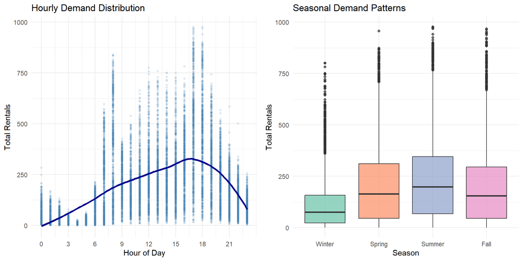

```r
p1 <- ggplot(bike, aes(x = as.numeric(as.character(hour)), y = count)) +
  geom_point(alpha = 0.15, color = "steelblue", size = 1) +
  geom_smooth(method = "loess", se = TRUE, color = "darkblue", linewidth = 1.2) +
  scale_x_continuous(breaks = seq(0, 23, by = 3)) +
  labs(title = "Hourly Demand Distribution",
       x = "Hour of Day", y = "Total Rentals") +
  theme_minimal()

p2 <- ggplot(bike, aes(x = season, y = count, fill = season)) +
  geom_boxplot(alpha = 0.7) +
  scale_fill_brewer(palette = "Set2") +
  labs(title = "Seasonal Demand Patterns",
       x = "Season", y = "Total Rentals") +
  theme_minimal() +
  theme(legend.position = "none")

grid.arrange(p1, p2, ncol = 2)
```

## 4.2 Weather Effects

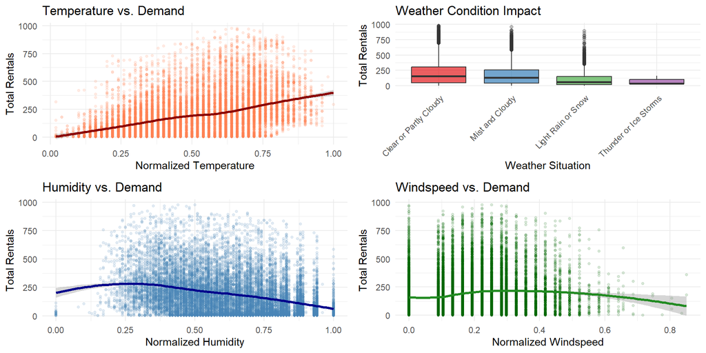

```r
p3 <- ggplot(bike, aes(x = temp, y = count)) +
  geom_point(alpha = 0.15, color = "coral", size = 1) +
  geom_smooth(method = "loess", se = TRUE, color = "darkred", linewidth = 1.2) +
  labs(title = "Temperature vs. Demand",
       x = "Normalized Temperature", y = "Total Rentals") +
  theme_minimal()

p4 <- ggplot(bike, aes(x = weather, y = count, fill = weather)) +
  geom_boxplot(alpha = 0.7, outlier.alpha = 0.3) +
  scale_fill_brewer(palette = "Set1") +
  labs(title = "Weather Condition Impact",
       x = "Weather Situation", y = "Total Rentals") +
  theme_minimal() +
  theme(legend.position = "none", axis.text.x = element_text(angle = 45, hjust = 1))

p5 <- ggplot(bike, aes(x = humidity, y = count)) +
  geom_point(alpha = 0.15, color = "steelblue", size = 1) +
  geom_smooth(method = "loess", se = TRUE, color = "darkblue", linewidth = 1.2) +
  labs(title = "Humidity vs. Demand",
       x = "Normalized Humidity", y = "Total Rentals") +
  theme_minimal()

p6 <- ggplot(bike, aes(x = windspeed, y = count)) +
  geom_point(alpha = 0.15, color = "darkgreen", size = 1) +
  geom_smooth(method = "loess", se = TRUE, color = "forestgreen", linewidth = 1.2) +
  labs(title = "Windspeed vs. Demand",
       x = "Normalized Windspeed", y = "Total Rentals") +
  theme_minimal()

grid.arrange(p3, p4, p5, p6, ncol = 2)
```

## 4.3 Holiday and Working Day Patterns

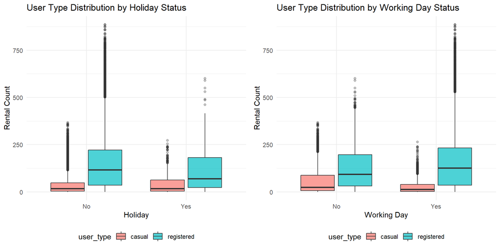

```r
# Reshape data for comparison
bike_long <- bike %>%
  select(holiday, workingday, casual, registered) %>%
  pivot_longer(cols = c(casual, registered),
               names_to = "user_type",
               values_to = "count")

p7 <- ggplot(bike_long, aes(x = holiday, y = count, fill = user_type)) +
  geom_boxplot(alpha = 0.7, outlier.alpha = 0.3) +
  labs(title = "User Type Distribution by Holiday Status",
       x = "Holiday", y = "Rental Count") +
  theme_minimal() +
  theme(legend.position = "bottom")

p8 <- ggplot(bike_long, aes(x = workingday, y = count, fill = user_type)) +
  geom_boxplot(alpha = 0.7, outlier.alpha = 0.3) +
  labs(title = "User Type Distribution by Working Day Status",
       x = "Working Day", y = "Rental Count") +
  theme_minimal() +
  theme(legend.position = "bottom")

grid.arrange(p7, p8, ncol = 2)
```

# 5 Correlation Analysis

Before building predictive models, we examine correlations between candidate predictors and the response variable (count) to develop more initial hypotheses, and analyze correlations among predictors to assess multicollinearity and guide feature selection.

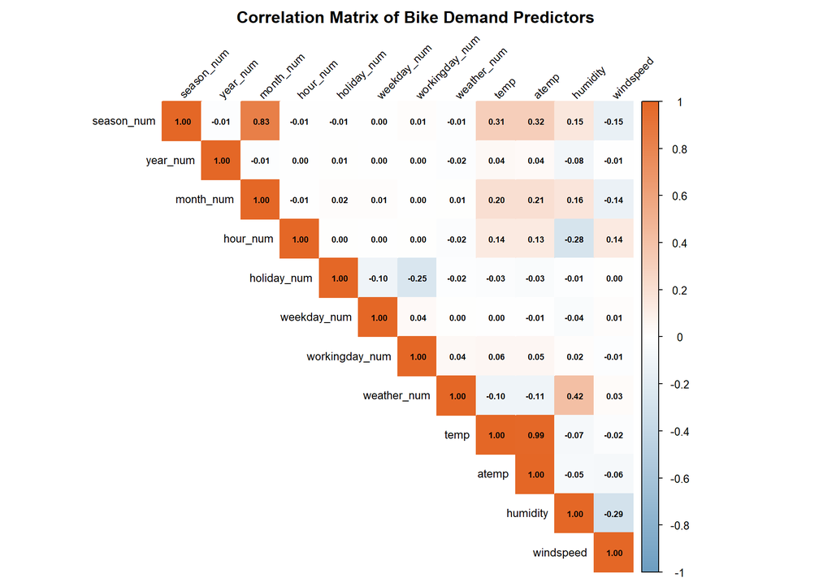

```r
# Create numeric version of key variables for correlation
bike_numeric <- bike %>%
  mutate(
    season_num     = as.numeric(season),
    year_num       = as.numeric(year),
    month_num      = as.numeric(month),
    hour_num       = as.numeric(hour),
    holiday_num    = as.numeric(holiday),
    weekday_num    = as.numeric(weekday),
    workingday_num = as.numeric(workingday),
    weather_num    = as.numeric(weather)
  ) %>%
  select(
    season_num, year_num, month_num, hour_num,
    holiday_num, weekday_num, workingday_num, weather_num,
    temp, atemp, humidity, windspeed, count
  )

# Calculate correlation matrix
cor_matrix <- cor(bike_numeric, use = "complete.obs")
cor_predictors <- cor(bike_numeric %>% select(-count), use = "complete.obs")

# Visualize correlation matrix
corrplot(
  cor_predictors,
  method       = "color",
  type         = "upper",
  tl.col       = "black",
  tl.srt       = 45,
  tl.cex       = 0.8,
  addCoef.col  = "black",
  number.cex   = 0.6,
  col          = colorRampPalette(c("#6D9EC1", "white", "#E46726"))(200),
  title        = "Correlation Matrix of Bike Demand Predictors",
  mar          = c(0, 0, 2, 0)
)
```

```r
# Build a data frame with variable names and their correlation with count
cor_with_count <- tibble(
  Variable    = rownames(cor_matrix),
  Correlation = cor_matrix[, "count"]
) %>%
  filter(Variable != "count") %>%
  arrange(desc(abs(Correlation)))

kable(
  head(cor_with_count, 20),
  digits  = 3,
  caption = "Correlations with Total Bike Demand"
)
```

Correlations with Total Bike Demand

| Variable | Correlation |
| --- | --- |
| temp | 0.405 |
| atemp | 0.401 |
| hour_num | 0.394 |
| humidity | -0.323 |
| year_num | 0.250 |
| season_num | 0.178 |
| weather_num | -0.142 |
| month_num | 0.121 |
| windspeed | 0.093 |
| holiday_num | -0.031 |
| workingday_num | 0.030 |
| weekday_num | 0.027 |

## 5.1 Correlations with Total Bike Demand

The exploratory data analysis conducted so far has already revealed several consistent patterns in bike usage. Building on these observations, a correlation analysis provides additional quantitative guidance on which factors are most closely related to total bike demand. The values below indicate direction and relative strength, and are used to inform the modeling stage rather than to draw final conclusions.

1. **Temperature and feeling tempeature (~0.40)**: Warmer and more comfortable conditions tend to be associated with higher bike usage, reinforcing patterns observed during the exploratory analysis.
2. **Time of day (0.39)**: Demand varies strongly throughout the day, reflecting clear daily routines and commuting behavior identified in earlier analyses.
3. **Humidity (–0.32)**: More humid conditions are linked to lower bike usage, suggesting that rider comfort plays a role in discouraging trips.
4. **Year (0.25)**: Demand shows an upward trend over time, consistent with overall system growth and increasing adoption.
5. **Seasonality (0.18)**: Seasonal differences are present but appear less influential than immediate weather conditions.
6. **Weather conditions (–0.14)**: Poor weather slightly reduces demand, though its overall impact remains limited.
7. **Month, windspeed, holidays, working day, weekday (≤ 0.12)**: These factors show weak standalone relationships with demand once daily routines and weather comfort are taken into account.

Together with the exploratory findings, these correlation-based signals guide the selection of variables and motivate the use of multiple predictive models to quantify their relative importance and support operational decision-making.

## 5.2 Multicollinearity Assessment among Predictors

Some predictors capture very similar information. When such overlap exists (referred to as multicollinearity), models can become harder to interpret and less stable, even if predictions remain accurate. To avoid this, we reviewed relationships among predictors and simplified the feature set by retaining the most meaningful and interpretable variables.

- **Temperature vs. Feeling temperature**: (`temp` vs. `atemp`, r ≈ 0.99) These variables move almost identically and represent the same underlying weather conditions, so we will just keep temp.
- **Month vs. Season**: (`month_num` vs. `season_num`, r ≈ 0.83) Both variables describe seasonal patterns and therefore provide overlapping information. We will therefore retain season, which offers a clearer and more intuitive representation.
- **Holiday vs. Working day** (`holiday_num` vs. `workingday_num`, r ≈ –0.25) These variables capture similar information, especially if we having also the weekday as a predictor. We will therefore retain holiday.

By removing overlapping predictors, we ensure the models remain robust, interpretable, and focused on variables that provide distinct insight into bike demand.

# 6 Model Development

## 6.1 Train-Test Split Strategy

To evaluate model performance objectively, we split the data into training (80%) and testing (20%) sets. The training set is used to fit models, while the testing set provides an unbiased assessment of how well models generalize to new data. This prevents overfitting, ensures fair comparison across models, and better reflects real operational conditions. The split is stratified so both sets preserve the same balance of high and low demand.

From a business perspective, this matters because a model that performs well in training but poorly on unseen data would be unreliable for planning bike availability, rebalancing, or staffing. The test set helps ensure we deploy models that work in practice, not just on paper.

```r
# Create stratified split for high_demand to ensure balanced classes
train_idx <- createDataPartition(bike$high_demand, p = 0.8, list = FALSE)
train <- bike[train_idx, ]
test <- bike[-train_idx, ]

cat(
  "Training observations: ", nrow(train), "\n",
  "Testing observations: ", nrow(test), "\n\n",
  "Class distribution in training and test sets:\n",
  paste(capture.output(prop.table(table(train$high_demand))), collapse = "\n"),
  paste(capture.output(prop.table(table(test$high_demand))), collapse = "\n")
)
```

```
Training observations:  13904
 Testing observations:  3475

 Class distribution in training and test sets:

      Low      High
0.5010788 0.4989212
      Low      High
0.5010072 0.4989928
```

## 6.2 Linear Model (LM) - Total Demand Forecasting

As we begin our predictive analysis, we first introduce a Linear Model (LM) as a baseline. Similar to a straight-line trend used in business forecasting, it allows us to understand direct, proportional relationships between operational factors (weather, time, and calendar effects) and bike demand.

The key advantage for Capital Bikeshare is interpretability: the Linear Model provides transparent coefficients showing how many additional bikes are expected with an increase in any predictor variable. This clarity helps your team easily identify the underlying drivers of demand and make confident, data-supported decisions.

```r
# Check if model already exists
if (file.exists("../models/lm_model.rds")) {
  lm_model <- readRDS("../models/lm_model.rds")
} else {

#Fit linear model
lm_model <- lm(count ~ season + year + hour + holiday + weekday +
                weather + temp + humidity + windspeed,
               data = train)
  # Save model
  saveRDS(lm_model, "../models/lm_model.rds")
}

#Key coefficients
summary(lm_model)
```

```
Call:
lm(formula = count ~ season + year + hour + holiday + weekday +
    weather + temp + humidity + windspeed, data = train)

Residuals:
    Min      1Q  Median      3Q     Max
-397.18  -60.59   -7.62   49.62  469.59

Coefficients:
                             Estimate Std. Error t value Pr(>|t|)
(Intercept)                   -87.471      6.924 -12.633  < 2e-16 ***
seasonSpring                   43.603      3.150  13.841  < 2e-16 ***
seasonSummer                   26.215      4.079   6.427 1.34e-10 ***
seasonFall                     64.532      2.723  23.696  < 2e-16 ***
year2012                       86.095      1.752  49.140  < 2e-16 ***
hour1                         -18.335      6.028  -3.042 0.002358 **
hour2                         -28.914      6.015  -4.807 1.55e-06 ***
hour3                         -39.147      6.021  -6.501 8.23e-11 ***
hour4                         -41.543      6.050  -6.866 6.87e-12 ***
hour5                         -24.470      5.982  -4.091 4.33e-05 ***
hour6                          34.701      5.961   5.821 5.97e-09 ***
hour7                         169.029      5.967  28.326  < 2e-16 ***
hour8                         309.212      5.963  51.854  < 2e-16 ***
hour9                         161.896      6.005  26.958  < 2e-16 ***
hour10                        109.407      5.997  18.243  < 2e-16 ***
hour11                        133.360      6.057  22.018  < 2e-16 ***
hour12                        171.777      6.076  28.273  < 2e-16 ***
hour13                        169.713      6.072  27.951  < 2e-16 ***
hour14                        152.082      6.149  24.735  < 2e-16 ***
hour15                        165.235      6.152  26.857  < 2e-16 ***
hour16                        222.812      6.138  36.298  < 2e-16 ***
hour17                        373.830      6.099  61.297  < 2e-16 ***
hour18                        347.093      6.108  56.827  < 2e-16 ***
hour19                        236.339      6.031  39.189  < 2e-16 ***
hour20                        154.951      5.970  25.953  < 2e-16 ***
hour21                        107.051      5.925  18.066  < 2e-16 ***
hour22                         72.278      5.940  12.167  < 2e-16 ***
hour23                         30.817      5.952   5.177 2.28e-07 ***
holidayYes                    -29.355      5.386  -5.450 5.12e-08 ***
weekdayMon                     10.786      3.329   3.240 0.001200 **
weekdayTue                     11.111      3.265   3.403 0.000668 ***
weekdayWed                     12.039      3.242   3.713 0.000205 ***
weekdayThu                     13.445      3.270   4.112 3.95e-05 ***
weekdayFri                     18.248      3.252   5.611 2.06e-08 ***
weekdaySat                     16.542      3.229   5.124 3.04e-07 ***
weatherMist and Cloudy         -9.368      2.148  -4.362 1.30e-05 ***
weatherLight Rain or Snow     -63.530      3.636 -17.475  < 2e-16 ***
weatherThunder or Ice Storms  -68.802     59.223  -1.162 0.245359
temp                          249.364      7.935  31.428  < 2e-16 ***
humidity                      -70.321      6.091 -11.545  < 2e-16 ***
windspeed                     -40.200      7.688  -5.229 1.73e-07 ***
---
Signif. codes:  0 '***' 0.001 '**' 0.01 '*' 0.05 '.' 0.1 ' ' 1

Residual standard error: 102.3 on 13863 degrees of freedom
Multiple R-squared:  0.6816,    Adjusted R-squared:  0.6807
F-statistic:   742 on 40 and 13863 DF,  p-value: < 2.2e-16
```

```r
# Predictions
lm_pred <- predict(lm_model, newdata = test)
lm_rmse <- sqrt(mean((test$count - lm_pred)^2))
lm_mae <- mean(abs(test$count - lm_pred))
lm_r_squared <- cor(test$count, lm_pred)^2

# Print results
cat(
  "Linear Model Performance:\n",
  "RMSE: ", round(lm_rmse, 2), "\n",
  "MAE:  ", round(lm_mae, 2), "\n",
  "R²:   ", round(lm_r_squared, 2)
)
```

```
Linear Model Performance:
 RMSE:  102.96
 MAE:   76.68
 R²:    0.68
```

### 6.2.1 Interpretation

Capital Bikeshare demand follows structured and predictable patterns. The Linear Model explains 68% of the variation in hourly ridership, and all key predictors show very small p-values, providing strong evidence that weather, time, and calendar effects meaningfully shape usage.

### 6.2.2 Business Value:

**Seasonal and Weather-Based Fleet Management**: Winter and adverse-weather periods naturally depress ridership. These low-utilization windows are well suited for preventive maintenance, repairs, battery service, and refurbishment. Bringing part of the fleet indoors during cold, snowy, or stormy periods protects equipment from weather-related wear while reducing unnecessary outdoor inventory. This ensures more bikes return to peak season in reliable condition and lowers long-term maintenance costs. **Commuter Peak Optimization**: The strong morning and evening commuter peaks indicate that fleet availability during 08:00 and 17:00/18:00 is critical for service reliability. Ensuring that bikes are positioned at key origin stations before the peaks, and that docks are available at destination stations afterward, helps prevent both shortages and full-dock failures. Low-demand hours (late night and early afternoon) are ideal for rebalancing, servicing, and repositioning bikes for the next peak cycle. **Bike Buffers**: The linear model is a great guide, but it isn’t perfect. Therefore we recommend keeping a Backup Buffer of about 77 bikes during normal hours, and up to 102 bikes during rush hours.

## 6.3 Poisson Generalized Linear Model - Casual Riders Modeling

Casual riders represent a meaningful growth segment for Capital Bikeshare, as their usage is driven by tourism and leisure rather than daily commuting. Because casual demand is recorded as hourly counts, we first considered a standard Poisson model. However, inspection of the dispersion parameter (φ ≈ 9.34) indicated that the variability in casual ridership was nearly ten times higher than a Poisson model would assume. This level of overdispersion would lead to overstated statistical significance and unreliable inference under a strict Poisson specification. We therefore estimated the model using a quasi-Poisson family, which adjusts for this excess variance and provides a more realistic representation of casual user behavior.

```r
# Check if model already exists
if (file.exists("../models/glm_quasipoisson.rds")) {
  glm_quasipoisson <- readRDS("../models/glm_quasipoisson.rds")
} else {
  # Fit quasipoisson GLM for casual users
  glm_quasipoisson <- glm(casual ~ season + year + hour + holiday + weekday +
                       weather + temp + humidity + windspeed,
                     family = quasipoisson(link = "log"),
                     data = train)
  # Save model
  saveRDS(glm_quasipoisson, "../models/glm_quasipoisson.rds")
}

# Key coefficients
summary(glm_quasipoisson)
```

```
Call:
glm(formula = casual ~ season + year + hour + holiday + weekday +
    weather + temp + humidity + windspeed, family = quasipoisson(link = "log"),
    data = train)

Coefficients:
                             Estimate Std. Error t value Pr(>|t|)
(Intercept)                   1.32687    0.05008  26.495  < 2e-16 ***
seasonSpring                  0.62797    0.01914  32.801  < 2e-16 ***
seasonSummer                  0.37414    0.02285  16.371  < 2e-16 ***
seasonFall                    0.51860    0.01763  29.419  < 2e-16 ***
year2012                      0.37121    0.00895  41.475  < 2e-16 ***
hour1                        -0.42888    0.06417  -6.683 2.43e-11 ***
hour2                        -0.72270    0.07058 -10.239  < 2e-16 ***
hour3                        -1.23923    0.08526 -14.535  < 2e-16 ***
hour4                        -2.06582    0.12327 -16.758  < 2e-16 ***
hour5                        -1.87603    0.11247 -16.680  < 2e-16 ***
hour6                        -0.80312    0.07350 -10.927  < 2e-16 ***
hour7                         0.16091    0.05470   2.942  0.00327 **
hour8                         0.79191    0.04778  16.573  < 2e-16 ***
hour9                         1.06920    0.04551  23.492  < 2e-16 ***
hour10                        1.41511    0.04356  32.490  < 2e-16 ***
hour11                        1.59828    0.04288  37.274  < 2e-16 ***
hour12                        1.69306    0.04269  39.656  < 2e-16 ***
hour13                        1.72282    0.04255  40.489  < 2e-16 ***
hour14                        1.78024    0.04266  41.728  < 2e-16 ***
hour15                        1.74497    0.04270  40.866  < 2e-16 ***
hour16                        1.73080    0.04277  40.468  < 2e-16 ***
hour17                        1.75537    0.04266  41.144  < 2e-16 ***
hour18                        1.60117    0.04301  37.232  < 2e-16 ***
hour19                        1.41845    0.04352  32.595  < 2e-16 ***
hour20                        1.15908    0.04460  25.985  < 2e-16 ***
hour21                        0.94365    0.04570  20.650  < 2e-16 ***
hour22                        0.75465    0.04745  15.903  < 2e-16 ***
hour23                        0.39422    0.05087   7.750 9.83e-15 ***
holidayYes                    0.57549    0.02488  23.135  < 2e-16 ***
weekdayMon                   -0.80566    0.01682 -47.908  < 2e-16 ***
weekdayTue                   -0.89952    0.01687 -53.321  < 2e-16 ***
weekdayWed                   -0.94645    0.01693 -55.916  < 2e-16 ***
weekdayThu                   -0.88847    0.01666 -53.333  < 2e-16 ***
weekdayFri                   -0.61050    0.01537 -39.729  < 2e-16 ***
weekdaySat                    0.08967    0.01265   7.089 1.42e-12 ***
weatherMist and Cloudy       -0.08064    0.01152  -6.999 2.70e-12 ***
weatherLight Rain or Snow    -0.62602    0.02560 -24.452  < 2e-16 ***
weatherThunder or Ice Storms -1.29697    1.08061  -1.200  0.23008
temp                          2.14521    0.04118  52.087  < 2e-16 ***
humidity                     -0.21234    0.03149  -6.742 1.62e-11 ***
windspeed                    -0.26090    0.03801  -6.864 6.99e-12 ***
---
Signif. codes:  0 '***' 0.001 '**' 0.01 '*' 0.05 '.' 0.1 ' ' 1

(Dispersion parameter for quasipoisson family taken to be 9.336931)

    Null deviance: 715395  on 13903  degrees of freedom
Residual deviance: 125723  on 13863  degrees of freedom
AIC: NA

Number of Fisher Scoring iterations: 5
```

```r
# Predictions and performance
glm_quasipois_pred <- predict(glm_quasipoisson, newdata = test, type = "response")
glm_quasipois_rmse <- sqrt(mean((test$casual - glm_quasipois_pred)^2))
glm_quasipois_mae <- mean(abs(test$casual - glm_quasipois_pred))
glm_quasipois_r_squared <- cor(test$casual, glm_quasipois_pred)^2

cat(
  "Poisson GLM Performance:\n",
  "MAE: ", round(glm_quasipois_mae, 2), "\n",
  "R²:  ", round(glm_quasipois_r_squared, 2)
)
```

```
Poisson GLM Performance:
 MAE:  13.68
 R²:   0.73
```

### 6.3.1 Interpretation

Because we are modeling counts of casual riders, the raw numbers from this model require a mathematical transformation to make sense. To save you time, we have already performed these transformations so that the insights provided below are directly applicable to your business decisions

**Baseline Prediction**: Under baseline conditions (Winter, Sunday, midnight, clear weather, 2011), the model predicts about exp(1.327) ≈ 4 casual trips per hour.

**Key Demand Drivers**:

- **Hour of day**: Casual usage peaks strongly between 13:00 and 17:00, with coefficients around 1.7–1.8, corresponding to roughly 5–6× higher demand than midnight. Demand remains elevated into the evening (e.g., 18:00: ~5×, 19:00: ~4×) but tapers down gradually. This reflects a leisure/tourism pattern rather than commuter behavior.
- **Temperature**: Moving from a cold to a warm day (e.g. a 0.6 increase in the scaled temperature variable) multiplies casual demand by exp(2.15 × 0.6) ≈ 3.5×, showing strong weather sensitivity.
- **Annual growth**: In 2012, casual demand is exp(0.37) ≈ 1.45× higher than in 2011 after controlling for other factors – about 45% year-over-year growth in casual usage.
- **Holiday boost**: Holidays increase casual demand by exp(0.575) ≈ 1.78×, i.e. about +78%, confirming that holidays behave like “super-weekends” for leisure riders.

### 6.3.2 Business Value

- **Specific Marketing Campaigns**: Target mid-day and afternoon marketing campaigns toward tourists and leisure riders, especially on holidays and warm days when casual demand surges most strongly.
- **Operational Reliability and Capacity Planning**: From an operational perspective, the Poisson model predicts casual rider demand with an average error of roughly ±14 bikes per hour and captures approximately 73% of demand patterns. This level of predictive reliability supports weekend and holiday capacity planning, staffing, and redistribution decisions, while still allowing for real-time adjustment during unusual events (e.g., storms or festivals).
- **Casual Growth**: Importantly, the model reveals clear year-over-year growth in casual ridership. This sustained increase suggests that casual riders are not just opportunistic users but a strategic growth segment. As adoption expands, particularly among tourists and leisure riders, Capital Bikeshare may benefit from incremental fleet expansion and peak-season inventory increases to avoid shortages at high-demand destinations such as parks, museums, and waterfront stations.

## 6.4 Binomial Generalized Linear Model - User Composition

To analyze who drives demand at different times, we model the probability that an individual ride in a given hour is from a registered user rather than a casual rider. Each hour consists of a number of “trials” (rides), where each outcome is either registered (success) or casual (failure).

```r
# Define binomial response: successes = registered; failures = casual
train$reg_count   <- train$registered
train$total_count <- train$count

test$reg_count    <- test$registered
test$total_count  <- test$count

# Load or fit the Binomial GLM
if (file.exists("../models/glm_binomial.rds")) {
  glm_binomial <- readRDS("../models/glm_binomial.rds")
} else {
  glm_binomial <- glm(
    cbind(reg_count, total_count - reg_count) ~
      season + year + hour + holiday + weekday + weather + temp + humidity + windspeed,
    family = binomial(link = "logit"),
    data   = train
  )
  saveRDS(glm_binomial, "../models/glm_binomial.rds")
}

glm_binomial_coefs <- summary(glm_binomial)$coefficients

# Predictions on test set
glm_binom_prob <- predict(glm_binomial, newdata = test, type = "response")

# Classification: which group dominates?
glm_binom_pred_class <- ifelse(glm_binom_prob > 0.5, "registered-majority", "casual-majority")
glm_binom_true_class <- ifelse(test$registered > test$casual, "registered-majority", "casual-majority")
glm_binom_accuracy   <- mean(glm_binom_pred_class == glm_binom_true_class)

glm_binomial_coefs
```

```
                                 Estimate  Std. Error     z value      Pr(>|z|)
(Intercept)                   1.844073301 0.018839608  97.8827870  0.000000e+00
seasonSpring                 -0.285830516 0.006912961 -41.3470488  0.000000e+00
seasonSummer                 -0.064506960 0.008225136  -7.8426616  4.410955e-15
seasonFall                   -0.019717661 0.006380343  -3.0903763  1.999030e-03
year2012                      0.108671831 0.003412856  31.8418993 1.704135e-222
hour1                         0.036136674 0.023788906   1.5190557  1.287485e-01
hour2                        -0.013400690 0.026343438  -0.5086918  6.109683e-01
hour3                        -0.205119437 0.032364476  -6.3377957  2.330756e-10
hour4                        -0.217858038 0.045987442  -4.7373376  2.165442e-06
hour5                         0.629065633 0.038990293  16.1339038  1.474014e-58
hour6                         0.858715167 0.025650208  33.4779024 1.010866e-245
hour7                         0.909565516 0.019522931  46.5895973  0.000000e+00
hour8                         0.797727004 0.017342879  45.9973804  0.000000e+00
hour9                         0.070865514 0.016785594   4.2218056  2.423531e-05
hour10                       -0.486294716 0.016336859 -29.7667204 1.053775e-194
hour11                       -0.530837140 0.016086995 -32.9979060 8.704009e-239
hour12                       -0.436549616 0.015967059 -27.3406402 1.395359e-164
hour13                       -0.487677592 0.015927983 -30.6176612 7.124277e-206
hour14                       -0.649580472 0.016034410 -40.5116549  0.000000e+00
hour15                       -0.551577809 0.016008869 -34.4545135 3.853956e-260
hour16                       -0.307185693 0.015952740 -19.2559832  1.257644e-82
hour17                        0.048631231 0.015838491   3.0704460  2.137394e-03
hour18                        0.149505430 0.015941225   9.3785409  6.689194e-21
hour19                        0.052384526 0.016130184   3.2476087  1.163792e-03
hour20                        0.005363398 0.016519540   0.3246699  7.454309e-01
hour21                       -0.026107846 0.016910437  -1.5438895  1.226151e-01
hour22                       -0.067381442 0.017550885  -3.8392047  1.234335e-04
hour23                       -0.089609281 0.018806447  -4.7648172  1.890250e-06
holidayYes                   -0.771153212 0.009866838 -78.1560653  0.000000e+00
weekdayMon                    0.866945959 0.006412401 135.1983414  0.000000e+00
weekdayTue                    0.964211323 0.006340283 152.0770101  0.000000e+00
weekdayWed                    1.019435160 0.006364853 160.1663336  0.000000e+00
weekdayThu                    0.953741162 0.006268934 152.1376985  0.000000e+00
weekdayFri                    0.707957139 0.005891752 120.1607181  0.000000e+00
weekdaySat                   -0.029581939 0.005130798  -5.7655635  8.138545e-09
weatherMist and Cloudy        0.005839346 0.004328430   1.3490681  1.773151e-01
weatherLight Rain or Snow     0.151456940 0.009294508  16.2953154  1.065526e-59
weatherThunder or Ice Storms  0.667055697 0.361010500   1.8477460  6.463910e-02
temp                         -1.550180564 0.015934839 -97.2824717  0.000000e+00
humidity                      0.174855361 0.012102525  14.4478416  2.586652e-47
windspeed                     0.167704695 0.014607751  11.4805278  1.652685e-30
```

```r
cat("Binomial GLM accuracy:", round(glm_binom_accuracy, 3), "\n")
```

```
Binomial GLM accuracy: 0.972
```

### 6.4.1 Interpretation

**Baseline Prediction**: Under winter, midnight, non-holiday, non-working-day, clear-weather conditions, the model predicts a registered-user share of 86%.

**Key Demand Drivers**:

- **Weekday**: Registered riders commute on weekdays much more than on saturday and sundays, confirming strong commuter dominance.
- **Hour of day**: During the morning peak (5–8 AM), the likelihood of being registered riders nearly doubles, while during midday (10 AM–3 PM), that registered dominance drops by about half as casual riders take over the system.
- **Season**: Spring and Summer reduce the registered share relative to winter by exp(-0.285 to -0.064), representing a 6–25% reduction in odds, reflecting higher casual/tourist activity.
- **Weather**: Light rain/snow increases the registered share by exp(0.151), 1.16× odds, as casual users drop off more quickly than commuters.
- **Temperature**: Warmer conditions reduce the registered share by exp(-1.550), 0.21× odds, a strong 79% shift toward casual riders for every unit increase in normalized temperature.

Overall, the model achieves high accuracy, capturing clear commuter vs. leisure behavior patterns across time, weather, and seasonality.

### 6.4.2 Business Value

This model identifies who uses the service under which conditions, enabling targeted operational and marketing actions:

- **Commuter segments**: High accuracy in predicting morning and working-day peaks supports corporate plans, commuter passes, and weekday-focused resource allocation.
- **Tourist/leisure segments**: Warm midday hours are dominated by casual riders, ideal for tourist promotions, flexible passes, and leisure-focused campaigns.
- **Operational optimization**: The 97.2% accuracy allows the system to confidently redistribute bikes based on the dominant rider type, prioritizing commuter routes in the morning and leisure/tourist zones during warm afternoons.

## 6.5 Generalized Additive Model - Nonlinear Weather Impacts on Demand

To capture nonlinear relationships between weather conditions and bike demand, we use a Generalized Additive Model (GAM). This model allows flexible smooth functions for temperature, humidity, and wind speed, while keeping seasonal and calendar effects linear. GAMs are ideal when relationships are curved or seasonal patterns vary gradually.

```r
# Load or fit the GAM model
if (file.exists("../models/gam_model.rds")) {
  gam_model <- readRDS("../models/gam_model.rds")
} else {
  gam_model <- gam(
    count ~
      s(temp) +
      s(humidity) +
      s(windspeed) +
      season + year + hour + holiday + weekday + weather,
    data = train,
    family = poisson(link = "log")
  )
  saveRDS(gam_model, "../models/gam_model.rds")
}

summary(gam_model)
```

```
Family: poisson
Link function: log

Formula:
count ~ s(temp) + s(humidity) + s(windspeed) + season + year +
    hour + holiday + weekday + weather

Parametric coefficients:
                              Estimate Std. Error  z value Pr(>|z|)
(Intercept)                   3.457210   0.006173  560.010  < 2e-16 ***
seasonSpring                  0.243379   0.002519   96.602  < 2e-16 ***
seasonSummer                  0.249028   0.003016   82.573  < 2e-16 ***
seasonFall                    0.376749   0.002277  165.440  < 2e-16 ***
year2012                      0.460162   0.001293  355.776  < 2e-16 ***
hour1                        -0.457885   0.009191  -49.819  < 2e-16 ***
hour2                        -0.834269   0.010418  -80.076  < 2e-16 ***
hour3                        -1.465517   0.013312 -110.087  < 2e-16 ***
hour4                        -2.100205   0.017825 -117.822  < 2e-16 ***
hour5                        -0.919785   0.010826  -84.958  < 2e-16 ***
hour6                         0.426695   0.007345   58.093  < 2e-16 ***
hour7                         1.444504   0.006268  230.444  < 2e-16 ***
hour8                         1.931426   0.005996  322.121  < 2e-16 ***
hour9                         1.391180   0.006258  222.319  < 2e-16 ***
hour10                        1.128550   0.006419  175.814  < 2e-16 ***
hour11                        1.261383   0.006328  199.320  < 2e-16 ***
hour12                        1.441561   0.006231  231.358  < 2e-16 ***
hour13                        1.433610   0.006226  230.268  < 2e-16 ***
hour14                        1.370679   0.006296  217.716  < 2e-16 ***
hour15                        1.420343   0.006264  226.749  < 2e-16 ***
hour16                        1.625214   0.006159  263.859  < 2e-16 ***
hour17                        2.036092   0.005996  339.564  < 2e-16 ***
hour18                        1.961529   0.006003  326.754  < 2e-16 ***
hour19                        1.656030   0.006093  271.792  < 2e-16 ***
hour20                        1.351974   0.006240  216.649  < 2e-16 ***
hour21                        1.104605   0.006388  172.906  < 2e-16 ***
hour22                        0.861908   0.006624  130.115  < 2e-16 ***
hour23                        0.468574   0.007114   65.870  < 2e-16 ***
holidayYes                   -0.145917   0.004173  -34.971  < 2e-16 ***
weekdayMon                    0.045486   0.002418   18.808  < 2e-16 ***
weekdayTue                    0.061112   0.002355   25.948  < 2e-16 ***
weekdayWed                    0.064046   0.002348   27.280  < 2e-16 ***
weekdayThu                    0.075501   0.002342   32.237  < 2e-16 ***
weekdayFri                    0.099394   0.002341   42.451  < 2e-16 ***
weekdaySat                    0.094760   0.002339   40.508  < 2e-16 ***
weatherMist and Cloudy       -0.047639   0.001586  -30.034  < 2e-16 ***
weatherLight Rain or Snow    -0.408640   0.003321 -123.057  < 2e-16 ***
weatherThunder or Ice Storms -0.278998   0.067117   -4.157 3.23e-05 ***
---
Signif. codes:  0 '***' 0.001 '**' 0.01 '*' 0.05 '.' 0.1 ' ' 1

Approximate significance of smooth terms:
               edf Ref.df Chi.sq p-value
s(temp)      8.264  8.809  73734  <2e-16 ***
s(humidity)  8.990  9.000   9382  <2e-16 ***
s(windspeed) 7.968  8.449   1708  <2e-16 ***
---
Signif. codes:  0 '***' 0.001 '**' 0.01 '*' 0.05 '.' 0.1 ' ' 1

R-sq.(adj) =   0.77   Deviance explained = 81.3%
UBRE = 30.144  Scale est. = 1         n = 13904
```

```r
# Predictions and performance
gam_pred <- predict(gam_model, newdata = test, type = "response")
gam_rmse <- sqrt(mean((test$count - gam_pred)^2))
gam_mae  <- mean(abs(test$count - gam_pred))
gam_r_squared <- cor(test$count, gam_pred)^2

cat(
  "GAM Performance:\n",
  "RMSE: ", round(gam_rmse, 2), "\n",
  "MAE:  ", round(gam_mae, 2), "\n",
  "R²:   ", round(gam_r_squared, 2)
)
```

```
GAM Performance:
 RMSE:  86.89
 MAE:   58.65
 R²:    0.77
```

### 6.5.1 Interpretation

**Key Demand Drivers**:

- **Season**: Compared to winter, demand increases by exp(0.243) ≈ 1.27× in spring, exp(0.249) ≈ 1.28× in summer, and exp(0.376) ≈ 1.46× in fall, confirming overall higher usage in warmer seasons.
- **Hour of day**: Demand is very low in the early night (e.g., hour 3: $\beta$ = –1.465). From the morning commute onwards it rises sharply, with peaks around hour 8 ($\beta$ = 1.931 → exp ≈ 6.9×) and hour 17/18 ($\beta$ = 2.036 → exp ≈ 7.6×) relative to midnight, capturing strong rush-hour patterns.
- **Holidays and Weekdays**: Holidays slightly reduce demand ($\beta$ = –0.145 → exp ≈ 0.86×). Working days show a small positive effect; for example, Friday increases demand by exp(0.099) ≈ 1.10×.
- **Weather (parametric)**: Mist/Cloudy conditions have a small negative effect ($\beta$ = –0.047 → exp ≈ 0.95×). Light rain or snow reduces expected demand by about 33.5% ($\beta$ = –0.408 → exp ≈ 0.665×), while severe storms reduce it by approximately 24.3% ($\beta$ = -0.278 → exp ≈ 0.757×).

**Smooth weather effects (nonlinear terms)**: All smooth terms are highly significant (p < 2e-16), showing strong nonlinear relationships: - **s(temp)**: Demand rises steeply from cold to mild conditions and then flattens or slightly declines at very high temperatures. - **s(humidity)**: Moderate humidity supports demand, while very high humidity strongly reduces it. - **s(windspeed)**: Light wind has little impact, but higher wind speeds reduce demand in a nonlinear way.

Overall, the GAM captures both sharp hourly peaks and smooth nonlinear weather effects, improving the fit compared to purely linear models, as evidenced by a Deviance explained of 81.3% and an R² of 0.77.

### 6.5.2 Business Value

The GAM provides a detailed picture of how many bikes are needed under specific weather and time conditions:

- **Weather-sensitive planning**: Operators can anticipate demand spikes when temperatures move from cold to mild and prepare for drops during heavy rain, high humidity, or strong winds.
- **Rush-hour capacity management**: Clear peak factors (up to ~7× midnight demand) support precise staffing and bike rebalancing during morning and evening commutes.
- **Seasonal and promotional timing**: Higher demand in spring, summer, and fall, combined with temperature–humidity curves, helps schedule leisure-focused campaigns and discounts when riders are most responsive.
- **Resilient operations**: By modelling nonlinear responses, the GAM enables more robust forecasting for unusual weather days, reducing both shortages and excess of bikes.

## 6.6 Neural Network - High Demand Classification

Neural networks are well suited for recognizing complex patterns in the data. In our case, the model predicts whether demand will be High (above the median) or Low. A compact neural network with a single hidden layer (8 neurons) was selected, which is sufficient for this type of tabular forecasting problem without introducing unnecessary complexity. Additional experiments showed that deeper architectures did not deliver noticeable gains in classification performance, making the simpler configuration both effective and efficient for Capital Bikeshare’s forecasting needs.

```r
## Prepare data with numeric predictors only with binary levels set at 0,1
train_nn <- train %>%
  mutate(
    season_num = as.numeric(season),
    year_num = as.numeric(year),
    hour_num = as.numeric(hour),
    holiday_num = as.numeric(holiday) - 1,
    weather_num = as.numeric(weather),
    high_demand_num = as.numeric(high_demand) - 1,
    weekday_num = as.numeric(weekday)
  )

test_nn <- test %>%
  mutate(
    season_num = as.numeric(season),
    year_num = as.numeric(year),
    hour_num = as.numeric(hour),
    holiday_num = as.numeric(holiday) - 1,
    weather_num = as.numeric(weather),
    high_demand_num = as.numeric(high_demand) - 1,
    weekday_num = as.numeric(weekday)
  )

## Check if model already exists
if (file.exists("../models/nn_model.rds")) {
  nn_model <- readRDS("../models/nn_model.rds")
} else {
  ## Fit neural network (single hidden layer with 8 nodes)
  nn_model <- nnet(high_demand_num ~ season_num + year_num + hour_num + holiday_num
                   + weather_num + temp + humidity + windspeed + weekday_num,
                   data = train_nn,
                   size = 8,
                   maxit = 200,
                   trace = FALSE)
  ## Save model
  saveRDS(nn_model, "../models/nn_model.rds")
}

nn_pred_prob <- predict(nn_model, newdata = test_nn, type = "raw")
nn_pred_class <- ifelse(nn_pred_prob > 0.5, "High", "Low")

## Create confusion matrix object with metrics
nn_conf_metrics <- confusionMatrix(
  data = factor(nn_pred_class, levels = c("Low", "High")),
  reference = factor(test$high_demand, levels = c("Low", "High")),
  positive = "High"  # Define which class is "positive"
)
nn_accuracy <- nn_conf_metrics$overall['Accuracy']

print(nn_conf_metrics)
```

```
Confusion Matrix and Statistics

          Reference
Prediction  Low High
      Low  1548  114
      High  193 1620

               Accuracy : 0.9117
                 95% CI : (0.9017, 0.9209)
    No Information Rate : 0.501
    P-Value [Acc > NIR] : < 2.2e-16

                  Kappa : 0.8233

 Mcnemar's Test P-Value : 8.52e-06

            Sensitivity : 0.9343
            Specificity : 0.8891
         Pos Pred Value : 0.8935
         Neg Pred Value : 0.9314
             Prevalence : 0.4990
         Detection Rate : 0.4662
   Detection Prevalence : 0.5217
      Balanced Accuracy : 0.9117

       'Positive' Class : High
```

### 6.6.1 Interpretation

The model captures complex relationships and interactions, achieving 91% balanced accuracy, confirming that the model performs consistently across both high and low demand classes. It successfully identifies 93% of high-demand hours. This enables proactive bike redistribution, though 193 false alarms (11% false positive rate) suggest occasional over-preparation.

### 6.6.2 Business Value

Trigger alerts for high-demand shifts, enabling proactive bike redistribution. This model is appropriate for operational planning because underestimating demand is more costly than over-preparing. For this reason, we do not only look at the accuracy but also at the sensitivity, which in this case is even higher than the accuracy.

## 6.7 Support Vector Machine and Cross Validation - High Demand Classification

Additional to the conclusions drawn from the Neural Networks, we provide a complementary perspective by comparing a Linear Support Vector Machine with a Radial Support Vector Machine, and subsequently validating the results using Cross-Validation.

### 6.7.1 Linear vs. Radial SVM

A Linear Support Vector Machine is well-suited when the separation between high and low demand can be approximated by a straight decision boundary. In contrast, a Radial Support Vector Machine offers more flexibility, as the radial basis function introduces an additional non-linear transformation of the feature space, allowing for curved or more complex separation boundaries.

```r
# Used e1071
# Check if model already exists
if (file.exists("../models/svm_linear.rds")) {
  svm_linear <- readRDS("../models/svm_linear.rds")
} else {

# Fit linear SVM with default cost 1
svm_linear <- svm(
  high_demand ~ season + year + hour + holiday + weekday +
    weather + temp + humidity + windspeed,
  data = train,
  kernel = "linear",
  cost = 1 #default
)
  ## Save model
  saveRDS(svm_linear, "../models/svm_linear.rds")
}

pred_linear <- predict(svm_linear, newdata = test)

cm_linear <- confusionMatrix(
  data = factor(pred_linear, levels = c("Low", "High")),
  reference = factor(test$high_demand, levels = c("Low", "High")),
  positive = "High"
)

cm_linear
```

```
Confusion Matrix and Statistics

          Reference
Prediction  Low High
      Low  1500  167
      High  241 1567

               Accuracy : 0.8826
                 95% CI : (0.8714, 0.8931)
    No Information Rate : 0.501
    P-Value [Acc > NIR] : < 2.2e-16

                  Kappa : 0.7652

 Mcnemar's Test P-Value : 0.0003015

            Sensitivity : 0.9037
            Specificity : 0.8616
         Pos Pred Value : 0.8667
         Neg Pred Value : 0.8998
             Prevalence : 0.4990
         Detection Rate : 0.4509
   Detection Prevalence : 0.5203
      Balanced Accuracy : 0.8826

       'Positive' Class : High
```

```r
svm_linear_accuracy <- cm_linear$overall['Accuracy']
```

```r
# Used e1071
# Check if model already exists
if (file.exists("../models/svm_radial.rds")) {
  svm_radial <- readRDS("../models/svm_radial.rds")
} else {

# Fit radial SVM with default cost 1 and default gamma 1/number of predictor variables
#(in this case 40 e.g. hours are counted as 24 already)
svm_radial<- svm(
  high_demand ~ season + year + hour + holiday + weekday +
    weather + temp + humidity + windspeed,
  data = train,
  kernel = "radial",
  cost = 1, #default
  gamma = 1/40 #default
)

  ## Save model
  saveRDS(svm_radial, "../models/svm_radial.rds")
}

pred_radial <- predict(svm_radial, newdata = test)

cm_radial <- confusionMatrix(
  data = factor(pred_radial, levels = c("Low", "High")),
  reference = factor(test$high_demand, levels = c("Low", "High")),
  positive = "High"
)

cm_radial
```

```
Confusion Matrix and Statistics

          Reference
Prediction  Low High
      Low  1471  158
      High  270 1576

               Accuracy : 0.8768
                 95% CI : (0.8654, 0.8876)
    No Information Rate : 0.501
    P-Value [Acc > NIR] : < 2.2e-16

                  Kappa : 0.7537

 Mcnemar's Test P-Value : 8.078e-08

            Sensitivity : 0.9089
            Specificity : 0.8449
         Pos Pred Value : 0.8537
         Neg Pred Value : 0.9030
             Prevalence : 0.4990
         Detection Rate : 0.4535
   Detection Prevalence : 0.5312
      Balanced Accuracy : 0.8769

       'Positive' Class : High
```

```r
svm_radial_accuracy <- cm_radial$overall['Accuracy']
```

The initial SVM models achieved prediction accuracies of approximately 88.3% for the Linear kernel and 87.7% for the Radial kernel, meaning that both approaches are already able to distinguish between high and low demand periods about 88% of the time. Since the Linear SVM performed slightly better and is also simpler to compute, it would be the preferred model at this early stage. However, these results were obtained using default settings and without tuning the cost (C) or gamma parameters that control model flexibility. In the next section, we will optimize these hyperparameters more systematically. As a result, these baseline figures should be viewed as preliminary: performance may improve once the models are tuned to better reflect Capital Bikeshare’s demand patterns.

### 6.7.2 Linear vs Radial SVM with Cross-Validation

While the initial results suggest both SVM models perform well, they rely on a single train/test split. To ensure these results are not simply due to a favorable partition of the data, we apply cross-validation using the caret library. This allows us to more rigorously compare the Linear and Radial SVMs and to tune the relevant hyperparameters (C for both models and gamma for the Radial kernel).

Using 5-fold cross-validation provides a more reliable indication of how each model is likely to perform in future demand scenarios, an important consideration for Capital Bikeshare as demand fluctuates with weather, season, and time of day.

```r
# Used caret
cv_control <- trainControl(
  method = "cv",
  number = 5
)

# Check if model already exists
if (file.exists("../models/svm_linear_cv.rds")) {
  svm_linear_cv<- readRDS("../models/svm_linear_cv.rds")
} else {

# Tune the cost hyperparameter
svm_linear_cv <- train(
  high_demand ~ season + year + hour + holiday + weekday +
    weather + temp + humidity + windspeed,
  data = train,
  method = "svmLinear",
  trControl = cv_control,
  preProcess = c("center", "scale"),
  tuneGrid = expand.grid(C = c(0.01, 0.1, 1, 10, 100)),
  metric = "Accuracy"
)

  ## Save model
  saveRDS(svm_linear_cv, "../models/svm_linear_cv.rds")
}

svm_linear_cv
```

```
Support Vector Machines with Linear Kernel

13904 samples
    9 predictor
    2 classes: 'Low', 'High'

Pre-processing: centered (40), scaled (40)
Resampling: Cross-Validated (5 fold)
Summary of sample sizes: 11122, 11123, 11123, 11124, 11124
Resampling results across tuning parameters:

  C      Accuracy   Kappa
  1e-02  0.8842780  0.7685765
  1e-01  0.8879458  0.7759078
  1e+00  0.8880895  0.7761948
  1e+01  0.8883772  0.7767700
  1e+02  0.8882334  0.7764830

Accuracy was used to select the optimal model using the largest value.
The final value used for the model was C = 10.
```

```r
svm_linear_cv_accuracy <- max(svm_linear_cv$results$Accuracy)
```

```r
# Used caret
# Check if model already exists
if (file.exists("../models/svm_radial_cv.rds")) {
  svm_radial_cv<- readRDS("../models/svm_radial_cv.rds")
} else {

# Tune the cost and sigma (gamma) hyperparameter
svm_radial_cv <- train(
  high_demand ~ season + year + hour + holiday + weekday +
    weather + temp + humidity + windspeed,
  data = train,
  method = "svmRadial",
  trControl = cv_control,
  preProcess = c("center", "scale"),
  tuneGrid = expand.grid(
    C = c(0.1, 1, 10, 100),
    sigma = c(0.01, 0.025, 0.05, 0.1) #in the default one it was 0.025 (1/40)
  ),
  metric = "Accuracy"
)

  ## Save model
  saveRDS(svm_radial_cv, "../models/svm_radial_cv.rds")
}

svm_radial_cv
```

```
Support Vector Machines with Radial Basis Function Kernel

13904 samples
    9 predictor
    2 classes: 'Low', 'High'

Pre-processing: centered (40), scaled (40)
Resampling: Cross-Validated (5 fold)
Summary of sample sizes: 11122, 11123, 11123, 11124, 11124
Resampling results across tuning parameters:

  C      sigma  Accuracy   Kappa
    0.1  0.010  0.8867954  0.7736308
    0.1  0.025  0.8967925  0.7936252
    0.1  0.050  0.8801065  0.7602812
    0.1  0.100  0.8673044  0.7347065
    1.0  0.010  0.9130462  0.8261047
    1.0  0.025  0.9249856  0.8499811
    1.0  0.050  0.9235471  0.8471052
    1.0  0.100  0.9166431  0.8332988
   10.0  0.010  0.9323933  0.8647919
   10.0  0.025  0.9284383  0.8568800
   10.0  0.050  0.9190881  0.8381815
   10.0  0.100  0.9080839  0.8161721
  100.0  0.010  0.9292292  0.8584607
  100.0  0.025  0.9162110  0.8324243
  100.0  0.050  0.9063571  0.8127153
  100.0  0.100  0.8944907  0.7889821

Accuracy was used to select the optimal model using the largest value.
The final values used for the model were sigma = 0.01 and C = 10.
```

```r
svm_radial_cv_accuracy <- max(svm_radial_cv$results$Accuracy)
```

```r
svm_compare <- resamples(
  list(
    Linear_SVM = svm_linear_cv,
    Radial_SVM = svm_radial_cv
  )
)

summary(svm_compare)
```

```
Call:
summary.resamples(object = svm_compare)

Models: Linear_SVM, Radial_SVM
Number of resamples: 5

Accuracy
                Min.   1st Qu.    Median      Mean   3rd Qu.      Max. NA's
Linear_SVM 0.8856115 0.8863718 0.8881697 0.8883772 0.8906475 0.8910855    0
Radial_SVM 0.9262590 0.9313197 0.9331416 0.9323933 0.9356115 0.9356347    0

Kappa
                Min.   1st Qu.    Median      Mean   3rd Qu.      Max. NA's
Linear_SVM 0.7712397 0.7727734 0.7763483 0.7767700 0.7813055 0.7821833    0
Radial_SVM 0.8525207 0.8626391 0.8662888 0.8647919 0.8712286 0.8712823    0
```

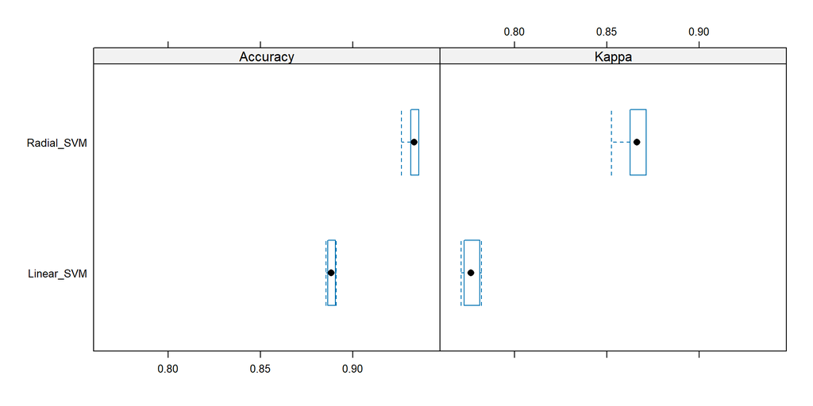

```r
bwplot(svm_compare)
```

#### 6.7.2.2 Business Value

From a business perspective, more accurate and stable demand forecasts help Capital Bikeshare ensure availability during high-demand periods and avoid excess inventory during low-demand periods, improving rebalancing decisions, staffing, and operational efficiency.

## 6.8 Overall Model Performance Summary

```r
# Compile all performance metrics
performance <- data.frame(
  Model = c("Linear Model", "GAM", "Poisson GLM", "Binomial GLM",
            "Neural Network", "Linear SVM", "Radial SVM", "Linear SVM with CV", "Radial SVM with CV"),
  Task = c("Total Demand", "Total Demand", "Casual Users", "User Composition",
           "High Demand Class", "High Demand Class", "High Demand Class", "High Demand Class", "High Demand Class"),
  Metric = c(paste("RMSE:", round(lm_rmse, 2)),
             paste("RMSE:", round(gam_rmse, 2)),
             paste("RMSE:", round(glm_quasipois_rmse, 2)),
             paste("Accuracy:", round(glm_binom_accuracy * 100, 1), "%"),
             paste("Accuracy:", round(nn_accuracy * 100, 1), "%"),
             paste("Accuracy:", round(svm_linear_accuracy * 100, 1), "%"),
             paste("Accuracy:", round(svm_radial_accuracy * 100, 1), "%"),
             paste("Accuracy:", round(svm_linear_cv_accuracy * 100, 1), "%"),
             paste("Accuracy:", round(svm_radial_cv_accuracy * 100, 1), "%")),
  Business_Use = c("Daily forecasting", "Weather-sensitive forecasting",
                   "Marketing targeting", "Membership strategy",
                   "Alert system", "Operational planning", "Operational planning", "Operational planning", "Operational planning")
)

performance %>%
  kable(caption = "Overall Model Performance Summary", align = "llll") %>%
  kable_styling(bootstrap_options = c("striped", "hover", "condensed", "responsive"))
```

Overall Model Performance Summary

| Model | Task | Metric | Business_Use |
| --- | --- | --- | --- |
| Linear Model | Total Demand | RMSE: 102.96 | Daily forecasting |
| GAM | Total Demand | RMSE: 86.89 | Weather-sensitive forecasting |
| Poisson GLM | Casual Users | RMSE: 24.84 | Marketing targeting |
| Binomial GLM | User Composition | Accuracy: 97.2 % | Membership strategy |
| Neural Network | High Demand Class | Accuracy: 91.2 % | Alert system |
| Linear SVM | High Demand Class | Accuracy: 88.3 % | Operational planning |
| Radial SVM | High Demand Class | Accuracy: 87.7 % | Operational planning |
| Linear SVM with CV | High Demand Class | Accuracy: 88.8 % | Operational planning |
| Radial SVM with CV | High Demand Class | Accuracy: 93.2 % | Operational planning |

# 7 Conclusions

The predictive models developed in this study provide Capital Bikeshare with a powerful toolkit for proactive decision-making. By employing specialized models for different operational needs, the system can transition from reactive troubleshooting to anticipated planning. These models are designed to be fed with forecasted variables like weather, holidays, and temporal data, making the system completely adjustable for predicting future needs and ensuring resources are always aligned with both commuters and leisure riders.

Overall, these results point to practical strategies that can be tested immediately. By utilizing the specific strengths of each model—from nonlinear weather analysis to high-demand classification, Capital Bikeshare can incorporate live variables such as weather forecasts and holiday schedules to adjust operations in advance. This multifaceted modeling framework makes it possible to look into the future, anticipate demand surges, and precisely inform how the system should respond in real time.

However, to ensure long-term success, several limitations and future considerations must be taken into account:

- **Geographic Specificity**: This study utilized hourly aggregates which mask significant station-level variations; obtaining the specific locations of the docks and stations would be highly valuable for developing neighborhood-specific models and improving redistribution logistics.
- **Data Recency**: The analysis is based on data from 2011 and 2012. More recent data would be instrumental, as modern post-pandemic transit behaviors and system expansions may differ significantly from these historical patterns.
- **Temporal Precision**: While hourly predictions capture broad trends, moving toward finer temporal granularity, such as 15-minute intervals, would be ideal for managing intra-hour variability during peak periods and further optimizing fleet readiness.

# 8 Teamcontributions and use of Generative AI

## 8.1 Teamcontributions

This project was completed collaboratively, with all members working together throughout the data preparation, analysis, modelling, and report writing process. While the work was shared collectively, each group member took the lead on the following models:

- **Ana**: Linear Model (LM), Support Vector Machine (SVM) with Cross Validation
- **Vani**: Generalized Linear Model (Poisson), Neural Network (NN)
- **Mayra**: Generalized Linear Model (Binomial), Generalized Additive Model (GAM)

All major decisions, interpretations, and final editing were discussed and completed jointly as a team.

## 8.2 Use of Genarative AI

We used Generative AI strictly as a supportive tool to complement our own work. For all modelling, coding, and interpretation tasks, we first attempted to solve them independently with help of the different labs seen in class. We only consulted AI when we needed clarification of error messages, help understanding unexpected behaviour in RMarkdown, or assistance rephrasing text to improve clarity. All statistical decisions, model specifications, and implementations were fully developed by us.

**Easy vs challenging**: AI was useful for simple and well-defined questions, but it was not capable of evaluating theoretical correctness. For example, during the Binomial GLM section, AI could give general explanations, but determining whether our response variable and predictors met the theoretical requirements for a proper binomial model was only possible after revisiting the lecture notes and course material. This conceptual validation required our own understanding and could not be outsourced.

**Critical reflection**: Throughout the project, we made sure to: - carefully review any explanations provided by AI - ensure that our interpretations were consistent with our dataset and modelling framework - verify all clarifications against the theory taught in class - maintain a unified writing style across team members and avoid any overly “AI-like” phrasing.

Overall, Generative AI provided limited but helpful support for minor clarifications and text refinement, while all core modelling work, statistical reasoning, and final decisions were entirely carried out by us based on the course content.